# ACP-159 Redes inalámbricas

Multiplexación TDM

Angel Gabrel Alvarado Lopez

06 de Diciembre 2023

# Multiplexación en el dominio del tiempo

Como se mencionó en la práctica anterior, existen dos tipos de multiplexación: en el dominio de la frecuencia y en el dominio del tiempo. La multiplexación en el dominio del tiempo, asigna a cada usuario, un intervalo de tiempo $\tau$, en el cual puede transmitir utilizando todo el ancho de banda del canal. La siguiente figura ilustra de mejor manera, la forma en que opera este tipo de multiplexación.

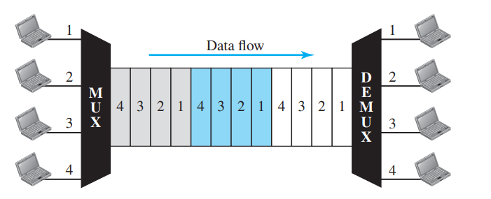

Como se puede observar, la multiplexación TDM, toma partes de la señal y las transmite a través del canal de comunicaciones. El principio de operación de la multiplexación TDM (para el caso analógico) es el teorema del muestreo, el cual de manera simplificada dice:

Se puede recuperar una señal $f(t)$(de banda limitada($F(\omega)=0$ para $\omega>\omega_B$)) siempre y cuando ésta se muestree con frecuecia $\omega \ge 2\omega_B$ o bien en intervalos $T \le 1/2\omega_B$. Al teorema del muestreo también se le conoce como el teorema de muestreo de Nyquist.

## Muestreo de señales

A continuación veremos la forma de muestrear una señal senoidal de frecuencia $f_0$. Supogamos que tenemos la siguiente señal

$$f(t) = \cos(4\pi t).$$

Primeramente, debemos observar que la señal coseno es una señal de banda limitada, con ancho de banda $f = 2$Hz, por lo tanto de acuerdo al teorema de muestreo de Nyquist, ésta debe muestrearse a una velocidad de por lo menos $4$Hz. Mostraremos en el siguiente código la forma de la señal orginal y el pulso la muestrará.

```r
x <- seq(0, 2 * 10 * 2 * pi, length = 1000)  #Se declara los pulsos, pulso de 20* 2pi <- de 0 a 2pi
sq <- square(x, duty = 20)  #filtro = Square
sq <- 0.5 * (1 + sq)  #Separacion del pulso.
t <- seq(0, 2, length = length(x))  #Señal del filtro en el tiempo.
ft <- cos(4 * pi * t)  #Señal origina de coseno(4pi).
highchart() %>%
    hc_add_series(cbind(t, sq), name = "Square") %>%
    hc_title(text = "Muestreo de señal \\(f(t) = \\cos(2\\pi f t)\\)", useHTML = T) %>%
    hc_add_theme(hc_theme_db()) %>%
    hc_xAxis(title = list(text = "Tiempo")) %>%
    hc_yAxis(title = list(text = "Valores", useHTML = T), min = -1.3, max = 1.3,
        allowDecimal = T) %>%
    hc_chart(zoomType = "xy") %>%
    hc_add_series(cbind(t, ft), name = "Información")
```

[interactive chart not shown]

```r
x <- seq(0, 2 * 10 * 2 * pi, length = 1000)
sq <- square(x, duty = 20)
sq <- 0.5 * (1 + sq)
t <- seq(0, 2, length = length(x))
ft <- cos(4 * pi * t)
samp <- sq * ft
highchart() %>%
    hc_add_series(cbind(t, samp), name = "Sampled") %>%
    hc_add_series(cbind(t, ft), dashStyle = "Dash", name = "Original", color = "#ffb703") %>%
    hc_title(text = "Muestreo de señal coseno", useHTML = T) %>%
    hc_add_theme(hc_theme_db()) %>%
    hc_xAxis(title = list(text = "Tiempo")) %>%
    hc_yAxis(title = list(text = "Valores", useHTML = T), min = -1.8, max = 1.8,
        allowDecimal = T) %>%
    hc_chart(zoomType = "xy")
```

[interactive chart not shown]

## Recuperación de señales muestreadas

Una señal muestreada puede recuperarse mediante un filtro pasabaja. Recordemos que un muestreo, al final de cuentas lo que provoca es enriquecer a las señal en el dominio de la frecuencia, replicando su espectro de acuerdo al período de muestreo. A continuación se muestra el proceso de recuperación de la señal coseno.

```r
library(gsignal)
library(highcharter)
x <- seq(0, 2 * 20 * 2 * pi, length = 1000)
sq <- square(x, duty = 20)
sq <- 0.5 * (1 + sq)
t <- seq(0, 2, length = length(x))
ft <- cos(4 * pi * t)
samp <- sq * ft
def <- butter(5, 0.02)
rec <- filter(def, samp)
highchart() %>%
    hc_add_series(cbind(t, 5 * rec), name = "Recovered") %>%
    hc_add_series(cbind(t, ft), dashStyle = "Dash", name = "Original", color = "#ffb703") %>%
    hc_title(text = "Recuperación de señal coseno", useHTML = T) %>%
    hc_add_theme(hc_theme_db()) %>%
    hc_xAxis(title = list(text = "Tiempo")) %>%
    hc_yAxis(title = list(text = "Valores", useHTML = T), min = -1.8, max = 1.8,
        allowDecimal = T) %>%
    hc_chart(zoomType = "xy")
```

[interactive chart not shown]

# Práctica:

Multiplexar las siguientes señales en el dominio del tiempo:

- $\cos(10\pi t)$
- $\cos(20\pi t)$
- $\frac{4}{\pi}\sin(6\pi t) + \frac{1}{3}\sin(18\pi t)$

# Tarea de la Multiplexacion en el dominio del tiempo:

Tomando en cuenta la siguientes señales: $\cos(10\pi t)$, $\cos(20\pi t)$ y $\frac{4}{\pi}\sin(6\pi t) + \frac{1}{3}\sin(18\pi t)$

```r
# Librerias usadas.
library(gsignal)
library(highcharter)

# Declaracion del tipo de filtro.
x <- seq(0, 2 * 30 * 9 * pi, length = 1000)
sq <- square(x, duty = 20)
sq <- 0.5 * (1 + sq)

# Declaracion de la ordenada.
t <- seq(0, 2, length = length(x))
ft1 <- cos(10 * pi * t)
ft2 <- cos(20 * pi * t)
ft3 <- (4/pi * (sin(6 * pi * t))) + (1/3 * (sin(18 * pi * t)))
samp <- sq * ft1 * ft2 * ft3

# Graficacion
highchart() %>%
    hc_add_series(cbind(t, samp), name = "Sampled", color = "#87ff65") %>%
    hc_add_series(cbind(t, ft1), dashStyle = "Dash", name = "Original", color = "#ffb703") %>%
    hc_add_series(cbind(t, ft2), dashStyle = "Dash", name = "Original 2", color = "#8338ec") %>%
    hc_add_series(cbind(t, ft3), dashStyle = "Dash", name = "Original 3", color = "#ff006e") %>%
    hc_title(text = "Muestreo de señal con filtro", useHTML = T) %>%
    hc_add_theme(hc_theme_monokai()) %>%
    hc_xAxis(title = list(text = "Tiempo")) %>%
    hc_yAxis(title = list(text = "Valores", useHTML = T), min = -1.8, max = 1.8,
        allowDecimal = T) %>%
    hc_chart(zoomType = "xy")
```

[interactive chart not shown]

Desglozando las señales anteriores se pueden separar de la siguiente forma:

- $\cos(10\pi t)$

```r
# Librerias usadas.
library(gsignal)
library(highcharter)

# Declaracion del tipo de filtro.
x <- seq(0, 2 * 30 * 9 * pi, length = 1000)
sq <- square(x, duty = 20)
sq <- 0.5 * (1 + sq)

# Declaracion de la ordenada.
t <- seq(0, 2, length = length(x))
ft1 <- cos(10 * pi * t)
# ft2 <- cos(20*pi*t) ft3 <- (4/pi*(sin(6*pi*t))) + (1/3* (sin(18*pi*t)))
samp <- sq * ft1

# Graficacion
highchart() %>%
    hc_add_series(cbind(t, samp), name = "Sampled", color = "#87ff65") %>%
    hc_add_series(cbind(t, ft1), dashStyle = "Dash", name = "Original cos(10pi t)",
        color = "#ffb703") %>%
    hc_title(text = "Muestreo de señal cos(10pi t)", useHTML = T) %>%
    hc_add_theme(hc_theme_monokai()) %>%
    hc_xAxis(title = list(text = "Tiempo")) %>%
    hc_yAxis(title = list(text = "Valores", useHTML = T), min = -1.8, max = 1.8,
        allowDecimal = T) %>%
    hc_chart(zoomType = "xy")
```

[interactive chart not shown]

- $\cos(20\pi t)$

```r
# Librerias usadas.
library(gsignal)
library(highcharter)

# Declaracion del tipo de filtro.
x <- seq(0, 2 * 30 * 9 * pi, length = 1000)
sq <- square(x, duty = 20)
sq <- 0.5 * (1 + sq)

# Declaracion de la ordenada.
t <- seq(0, 2, length = length(x))
# ft1 <- cos(10*pi*t)
ft2 <- cos(20 * pi * t)
# ft3 <- (4/pi*(sin(6*pi*t))) + (1/3* (sin(18*pi*t)))
samp <- sq * ft2

# Graficacion
highchart() %>%
    hc_add_series(cbind(t, samp), name = "Sampled", color = "#87ff65") %>%
    hc_add_series(cbind(t, ft2), dashStyle = "Dash", name = "Original cos(20pi t)",
        color = "#8338ec") %>%
    hc_title(text = "Muestreo de señal cos(20pi t)", useHTML = T) %>%
    hc_add_theme(hc_theme_monokai()) %>%
    hc_xAxis(title = list(text = "Tiempo")) %>%
    hc_yAxis(title = list(text = "Valores", useHTML = T), min = -1.8, max = 1.8,
        allowDecimal = T) %>%
    hc_chart(zoomType = "xy")
```

[interactive chart not shown]

- $\frac{4}{\pi}\sin(6\pi t) + \frac{1}{3}\sin(18\pi t)$

```r
# Librerias usadas.
library(gsignal)
library(highcharter)

# Declaracion del tipo de filtro.
x <- seq(0, 2 * 30 * 9 * pi, length = 1000)
sq <- square(x, duty = 20)
sq <- 0.5 * (1 + sq)

# Declaracion de la ordenada.
t <- seq(0, 2, length = length(x))
# ft1 <- cos(10*pi*t) ft2 <- cos(20*pi*t)
ft3 <- (4/pi * (sin(6 * pi * t))) + (1/3 * (sin(18 * pi * t)))
samp <- sq * ft3

# Graficacion
highchart() %>%
    hc_add_series(cbind(t, samp), name = "Sampled", color = "#87ff65") %>%
    hc_add_series(cbind(t, ft3), dashStyle = "Dash", name = "Original", color = "#ff006e") %>%
    hc_title(text = "Muestreo de señal original 4/pi(sin6pit) + (1/3 (sin18pit)",
        useHTML = T) %>%
    hc_add_theme(hc_theme_monokai()) %>%
    hc_xAxis(title = list(text = "Tiempo")) %>%
    hc_yAxis(title = list(text = "Valores", useHTML = T), min = -1.8, max = 1.8,
        allowDecimal = T) %>%
    hc_chart(zoomType = "xy")
```

[interactive chart not shown]

Señal post filtro

```r
# Librerias usadas.
library(gsignal)
library(highcharter)

# Configuracion del pulso.
x <- seq(0, 2 * 30 * 2 * pi, length = 1000)
sq <- square(x, duty = 20)
sq <- 0.5 * (1 + sq)
t <- seq(0, 2, length = length(x))

# Señales originales.
ft1 <- cos(10 * pi * t)
ft2 <- cos(20 * pi * t)
ft3 <- (4/pi * (sin(6 * pi * t))) + (1/3 * (sin(18 * pi * t)))

# Señales procesadas por el Square.
samp <- sq * ft1 * ft2 * ft3
def <- butter(5, 0.02)
rec <- filter(def, samp)

# Graficación de las variables.
highchart() %>%
    hc_add_series(cbind(t, 5 * rec), name = "Recovered", color = "#87ff65") %>%
    hc_add_series(cbind(t, ft1), dashStyle = "Dash", name = "Original 1", color = "#ffb703") %>%
    hc_add_series(cbind(t, ft2), dashStyle = "Dash", name = "Original 2", color = "#8338ec") %>%
    hc_add_series(cbind(t, ft3), dashStyle = "Dash", name = "Original 3", color = "#ff006e") %>%
    hc_title(text = "Recuperación de señal despues de filtro", useHTML = T) %>%
    hc_add_theme(hc_theme_monokai()) %>%
    hc_xAxis(title = list(text = "Tiempo")) %>%
    hc_yAxis(title = list(text = "Valores", useHTML = T), min = -1.8, max = 1.8,
        allowDecimal = T) %>%
    hc_chart(zoomType = "xy")
```

[interactive chart not shown]

Recuperacion de la señal

```r
# Librerias usadas.
library(gsignal)
library(highcharter)

# Configuracion del pulso.
x <- seq(0, 2 * 30 * 2 * pi, length = 1000)
sq <- square(x, duty = 20)
sq <- 0.5 * (1 + sq)
t <- seq(0, 2, length = length(x))

# Señales originales.
ft1 <- cos(10 * pi * t)
ft2 <- cos(20 * pi * t)
ft3 <- (4/pi * (sin(6 * pi * t))) + (1/3 * (sin(18 * pi * t)))

# Señales procesadas por el Square.
samp <- sq * ft1 * ft2 * ft3
samp1 <- samp/ft1
def <- butter(5, 0.02)
rec <- filter(def, samp)

# Graficación de las variables.
highchart() %>%
    hc_add_series(cbind(t, 5 * rec), name = "Recovered", color = "#87ff65") %>%
    hc_add_series(cbind(t, samp1), dashStyle = "Dash", name = "Original 1", color = "#ffb703") %>%
    hc_add_series(cbind(t, ft2), dashStyle = "Dash", name = "Original 2", color = "#8338ec") %>%
    hc_add_series(cbind(t, ft3), dashStyle = "Dash", name = "Original 3", color = "#ff006e") %>%
    hc_title(text = "Recuperación de señal", useHTML = T) %>%
    hc_add_theme(hc_theme_monokai()) %>%
    hc_xAxis(title = list(text = "Tiempo")) %>%
    hc_yAxis(title = list(text = "Valores", useHTML = T), min = -1.8, max = 1.8,
        allowDecimal = T) %>%
    hc_chart(zoomType = "xy")
```

[interactive chart not shown]